# Übungsaufgaben: Überlebenszeitanalyse

Raphael Schleutker und Hannah Schmitz

Oktober 2017

## Einleitung

### Kaplan-Meier-Plots: Überlebenszeitanalyse

Kaplan-Meier-Plots sollen dem Betrachter einen Eindruck davon verschaffen, wie wahrscheinlich ein bestimmtes Ereignis innerhalb eines Zeitraums eintritt. Insbesondere in der medizinischen Forschung werden sie dazu verwendet, Überlebenswahrscheinlichkeiten bei einer bestimmter Erkrankung darzustellen. Dazu werden diagnostizierte Patienten beobachtet. Es gibt zwei mögliche Ereignisse. Entweder verlässt ein Patient die Studie, beispielsweise weil er umzieht. Man sagt, der Patient ist zensiert. Oder der Patient stirb an der Krankheit. Für den eigentlichen Plot relevant sind nur die verstorbenen Patienten. Dennoch werden die zensierten Patienten häufig als Kreuze in dem Plot markiert. Die Überlebenswahrscheinlichkeit $\hat S(t)$ ist gegeben durch folgende Gleichung:

$$\hat S(t)=\prod_{t_i} \left( 1-\frac{d_i}{n_i}\right)$$

- $d_i =$ Patienten, die zum Zeitpunkt $t_i$ verstorben sind.
- $n_i =$ Patienten, die zum Zeitpunkt $t_i$ beobachtet werden.

### Das ggkm-Paket

Das Paket `ggkm` baut auf `ggplot2` auf, muss zusätzlich installiert werden und bietet im wesentlichen drei neue Geome:

- `geom_km()` fügt einem Diagramm einen Plot für die Überlebensrate hinzu.
- `geom_kmband()` fügt dem Diagramm ein Konfidenzintervall hinzu.
- `geom_kmticks()` fügt Kreuze für jedes Ereignis (Tod oder Zensur) hinzu.

Damit diese Geome funktionieren, müssen auf die x- und y-Achse die folgenden Werte gemapped werden:

- Auf die x-Achse kommt der Zeitraum (meist in Tagen) zwischen Diagnostik und Eintritt der Zensur oder des Todes. Dies passiert über `aes(time = ...)`.
- Auf die y-Achse kommt das Ereignis. Zensur / Tod ist entweder als `0` / `1` oder als `1` / `2` kodiert.

#### Installation

Das zentrale Archiv für R-Pakete ist CRAN (*Comprehensive R Archive Network*). Aus diesem lädt R die Pakete automatisch herunter. Manche Pakete sind allerdings nicht über CRAN installbierbar, sondern müssen aus anderen Quellen bezogen werden. Häufig ist dies [Github](https://github.com/). Github ist eine Seite, die es Entwicklern mithilfe des Versionsverwaltungsprogramms Git erleichtert, Software zu entwickeln. Die Stärke liegt hierbei vor allem darin, dass mehrere Personen gleichzeitig an einem Projekt arbeiten können (auch wir haben Git und Github genutzt, um diesen Workshop zu entwickeln). Um Pakete von Github zu installieren, kann man das Paket `devtools` benutzen. Hat man dieses installiert, kann man mit `devtools::install_github("sachsmc/ggkm")` das Paket `ggkm` installieren. **sachsmc** ist hierbei der Account-Name des Entwicklers.

### Der Datensatz

In dem Paket `survival` gibt es den Datensatz `lung`. Neben einigen weniger wichtigen Variablen besteht der Datensatz aus der Überlebenszeit der Personen sowie der Information, welches Ereignis nach der angegeben Zeit (Zensur oder Tod) bei ihnen eingetreten ist. Zusätzlich zeigen zwei Variablen das Alter und das Geschlecht an.

```r
head(survival::lung)
```

```
##   inst time status age sex ph.ecog ph.karno pat.karno meal.cal wt.loss
## 1    3  306      2  74   1       1       90       100     1175      NA
## 2    3  455      2  68   1       0       90        90     1225      15
## 3    3 1010      1  56   1       0       90        90       NA      15
## 4    5  210      2  57   1       1       90        60     1150      11
## 5    1  883      2  60   1       0      100        90       NA       0
## 6   12 1022      1  74   1       1       50        80      513       0
```

## Die Aufgaben

1. Stelle den `survival::lung`-Datensatz als Kaplan-Meier-Plot dar. Mappe dazu die Zeit-Variable auf die `time`-Achse und das Ereignis auf die `status`-Achse. Füge dann dem Diagramm die Überlebenswahrscheinlichkeit, die Kreuze für jedes Ereignis sowie das Konfidenzintervall hinzu.
2. Tausche anschließend die Reihenfolge der Geome, sodass das Konfidenzintervall als erstes in das Diagramm eingefügt wird. Was fällt dir auf?
3. Trenne den Plot in zwei Plots auf, indem du verschiedenen Farben für die Geschlechter verwendest.
4. `cut_width(x, width)` ist eine Hilfsfunktion aus dem `ggplot2`-Paket und unterteilt eine kontinuierliche Variable `x` in Kategorien mit der Länge `width`. Die Funktion wird statt der eigentlichen Variable auf eine Achse gemapped. Nutze dies, um ein altersabhängiges Überlebensdiagramm zu erstellen, wobei jeweils 10 Jahre in eine Kategorie zusammengefasst werden sollen. Lasse der Übersichtlichkeit halber die Konfidenzintervalle weg.
5. Ein weiterer Datensatz aus dem `survival`-Paket ist `myeloid`, welches simulierte Daten zur Überlebenswahrscheinlichkeit zu myeloider Leukämie enthält. Nutze diesen ebenfalls, um das Prinzip von Überlebensplots zu üben.

## Lösung

### Aufgabe 1

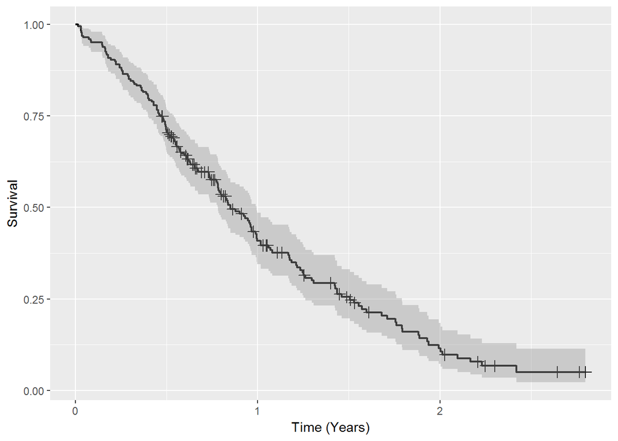

```r
library(ggplot2)
library(ggkm)
# Die Zeit wurde durch 365 geteilt, um die Zeit als Jahre anzuzeigen. Zusätzlich wurden die Achsen-Beschriftungen bearbeitet, um die verständlicher zu machen.

ggplot(lung, aes(time = time/365, status = status)) +
  geom_km() +
  geom_kmticks() +
  geom_kmband() +
  scale_x_continuous(name = "Time (Years)") +
  scale_y_continuous(name = "Survival")
```

### Aufgabe 2

Fügt man zuerst das teiltransparente Konfidenzintervall hinzu, werden die nachfolgenden Geome darüber gelegt. So werden sie nicht durch das Konfidenzintervall ‘ausgegraut’.

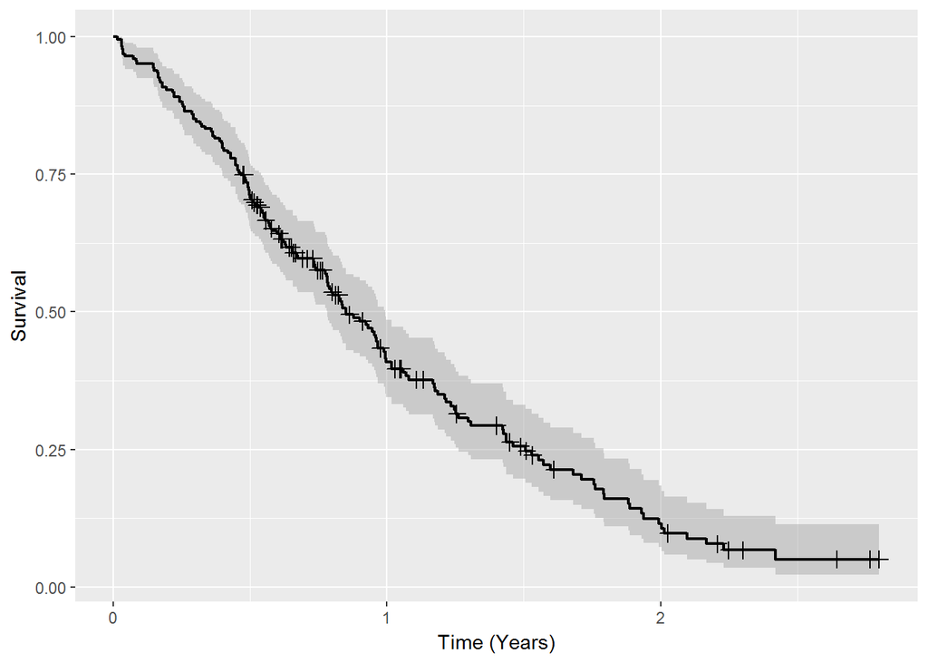

```r
library(ggplot2)
library(ggkm)


ggplot(lung, aes(time = time/365, status = status)) +
  geom_kmband() +
  geom_km() +
  geom_kmticks() +
  scale_x_continuous(name = "Time (Years)") +
  scale_y_continuous(name = "Survival")
```

### Aufgabe 3

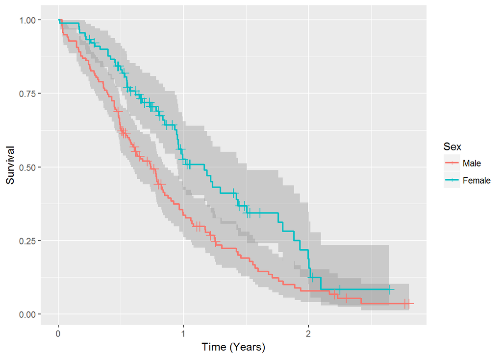

```r
library(ggplot2)
library(ggkm)

# Das Geschlecht ist über 1 und 2 kodiert und als numerische Variable gespeichert. Daher hilft die Funktion `as.factor()`, um die Variable für den Plot als Faktor zu behandeln.

ggplot(lung, aes(time = time/365, status = status, colour = as.factor(sex))) +
  geom_kmband() +
  geom_km() +
  geom_kmticks() +
  scale_color_discrete(name = "Sex", labels = c("Male", "Female")) +
  scale_x_continuous(name = "Time (Years)") +
  scale_y_continuous(name = "Survival")
```

### Aufgabe 4

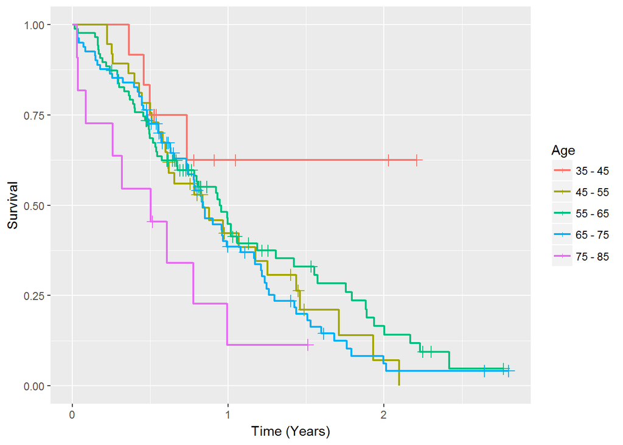

```r
library(ggplot2)
library(ggkm)


ggplot(lung, aes(time = time/365, status = status, colour = cut_width(age, width = 10))) +
  geom_km() +
  geom_kmticks() +
  scale_color_discrete(name = "Age", labels = c("35 - 45", "45 - 55", "55 - 65", "65 - 75", "75 - 85")) +
  scale_x_continuous(name = "Time (Years)") +
  scale_y_continuous(name = "Survival")
```